# Lab2

Jason Chen

2024-08-29

# Task 1

```r
  getwd()
```

```
## [1] "C:/Users/Jason Chen/Desktop/OU/OU24-25/Lab2"
```

# Task 2

```r
  epagas <- read.csv("EPAGAS.csv")
  head(epagas)
```

```
##    MPG
## 1 36.3
## 2 41.0
## 3 36.9
## 4 37.1
## 5 44.9
## 6 36.8
```

# Task 3

Make the object mpg, the number of miles per gallon vector

```r
  mpg <-epagas$MPG
  head(mpg)
```

```
## [1] 36.3 41.0 36.9 37.1 44.9 36.8
```

Transform mpg variable to z and verify these results

```r
  z <- (mpg - mean(mpg)) / sd(mpg)
  head(z)
```

```
## [1] -0.28702628  1.65681163 -0.03887676  0.04383975  3.26978352 -0.08023501
```

```r
  print(paste0("mean = ", round(mean(z), digits = 4)), quote =               FALSE)
```

```
## [1] mean = 0
```

```r
  print(paste0("variance = ", var(z)), quote = FALSE)
```

```
## [1] variance = 1
```

```r
  print(paste0("standard deviation = ", sd(z)), quote = FALSE)
```

```
## [1] standard deviation = 1
```

Using z, find values of mpg that are possible outliers

```r
  mpg[abs(z)>=2 & abs(z)<=3]
```

```
## [1] 30.0 42.1 31.8
```

Using z, find the values of mpg that are defined as outliers

```r
  mpg[abs(z)>3]
```

```
## [1] 44.9
```

Using the lattice package, construct a dotplot with colors

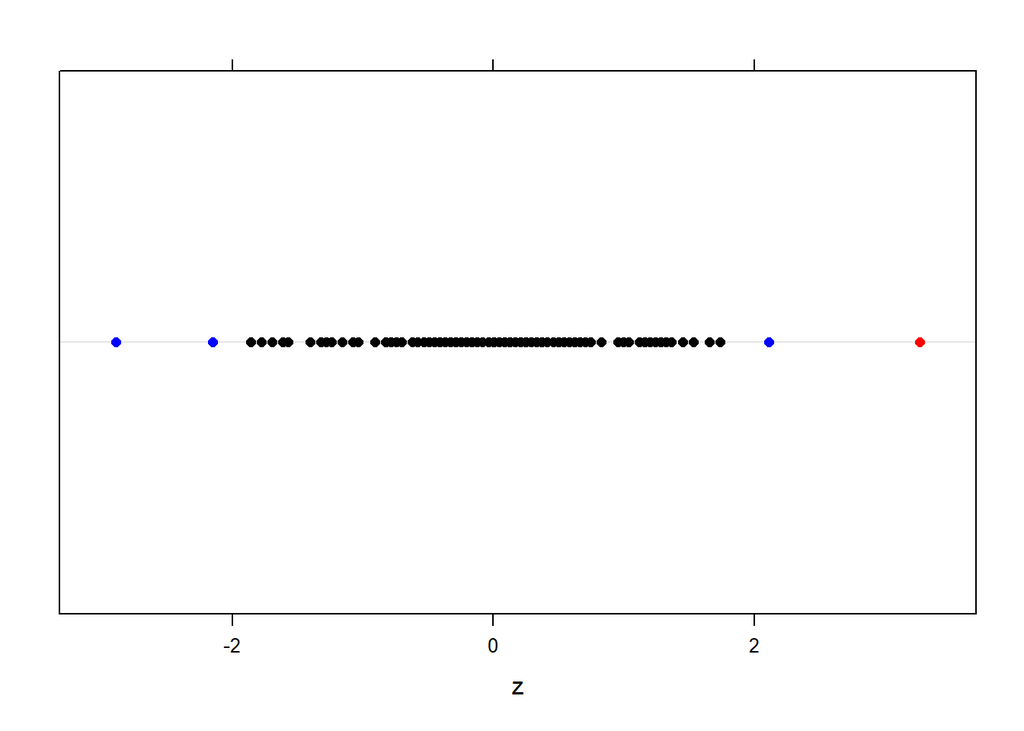

```r
  library(lattice)
  mycol = ifelse(abs(z)>3, "Red",
        ifelse(abs(z)>=2 &abs(z)<=3,"Blue", "Black"))
  dotplot(z, col=mycol)
```

# Task 4 Make a boxplot of the mpg variable - Make the box black - Put a notch where the median goes - Put a title on the graph - Make the plot horizontal

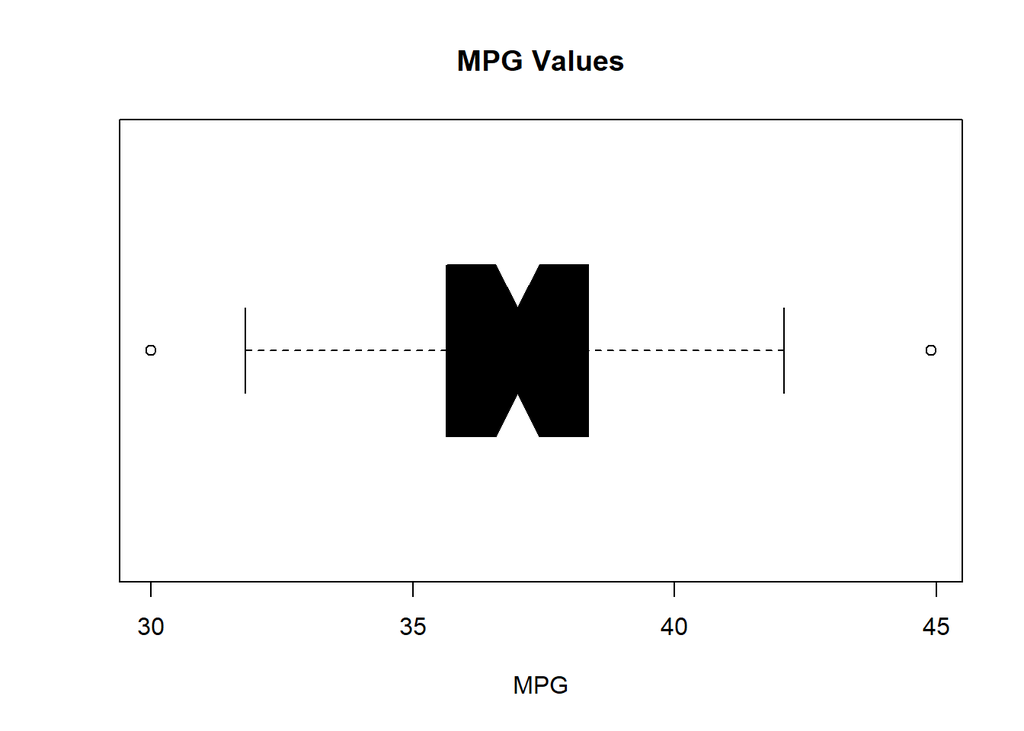

```r
  boxplot(mpg, main="MPG Values", xlab = "MPG", col = "BLACK", horizontal = TRUE, notch = TRUE)
```

Chebyshev’s Rule says that at least (1 - 1/k^2) of the measurements will fall within k standard deviations of the mean.

```r
  k = 2
  cheb <- 1 - 1 / (k ^ 2)
  cheb
```

```
## [1] 0.75
```

```r
  exact <- length(mpg[abs(z < 2)]) / length(mpg)
  exact
```

```
## [1] 0.98
```

The Empirical Rule says that approximately 95% of the measurements will lie within 2 standard deviations of the their mean given the dataset has an approximately mound-shaped, symmetric distribution.

The Empirical Rule is valid in this case because the dataset looks symmetrical and mound-shaped.

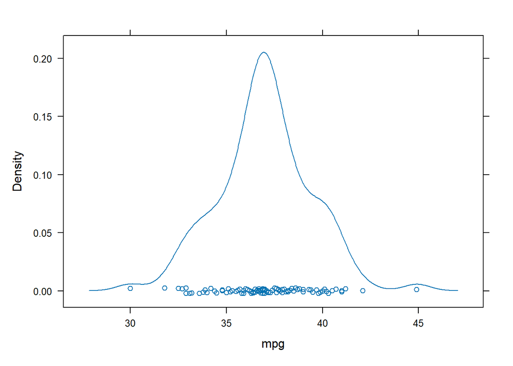

```r
  densityplot(mpg)
```